# Water and Economy Xiaojing Ni - Exploratory Data Analysis

Author

Xiaojing Ni

## Stream flow

#### Detect the trend

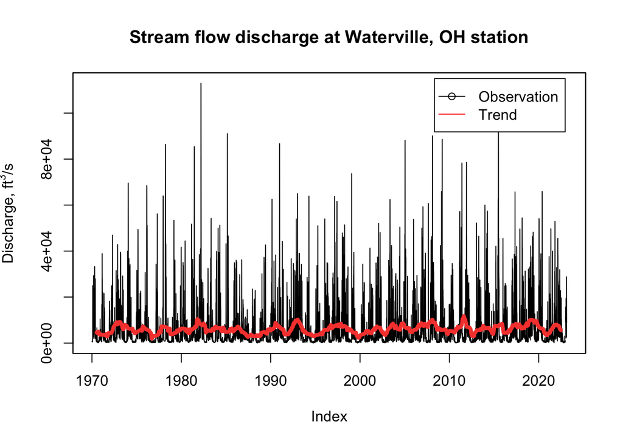

Figure 1: Stream flow discharge annual trend

```r
trend_discharge = ma(discharge_ts, order = 365, centre = T)
plot(discharge_ts, main="Stream flow discharge at Waterville, OH station",ylab=expression(paste("Discharge, ",ft^3,"/s",sep="")))
lines(trend_discharge, col = 2, lwd = 4)
legend(14000, 115000, legend=c("Observation", "Trend"),
       col=c("black", "red"), pch = c(1, NA),lty=1)
```

Figure 1 shows the daily stream flow trend obtained by moving average method with order of 365 (annual). There is no clear trend based on this figure.

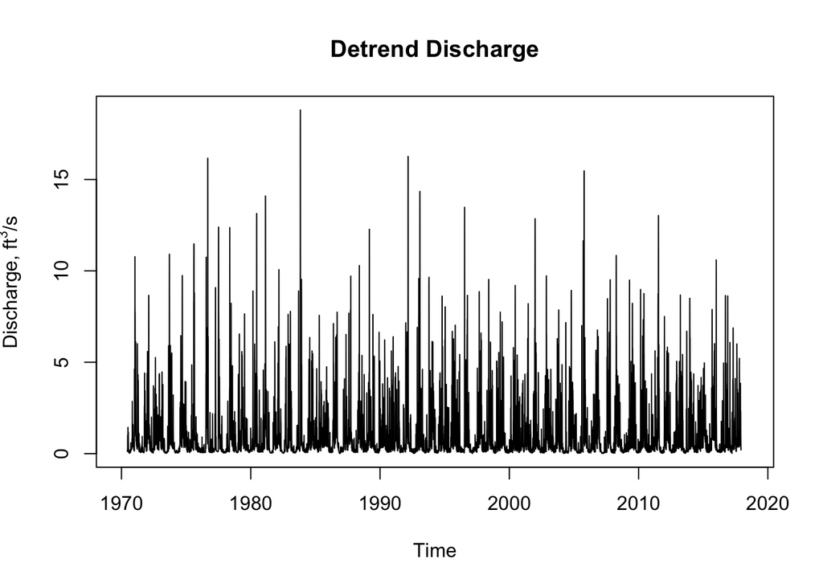

Figure 2: Stream flow discharge detrended series

```r
## detrend
x = seq(0,20000,20000/5)
y = seq(1970,2020,10)
detrend_discharge = discharge_ts/trend_discharge
plot(as.ts(detrend_discharge),xaxt='n',main="Detrend Discharge",ylab=expression(paste("Discharge, ",ft^3,"/s",sep="")))
axis(side = 1, at = x, labels = y)
```

#### Seasonality

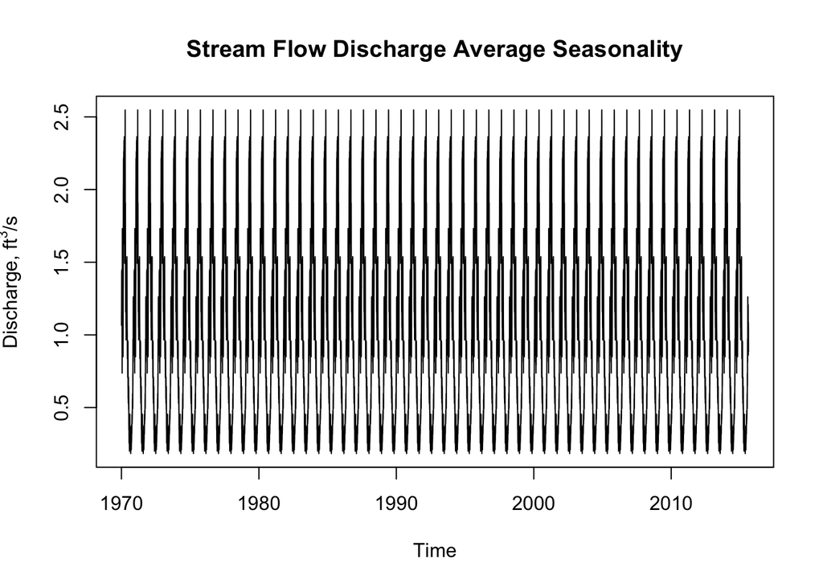

Figure 3: Stream flow discharge average seasonality

```r
## Average the Seasonality
m_discharge = t(matrix(data = detrend_discharge, nrow = 365))

seasonal_discharge = colMeans(m_discharge, na.rm = T)
plot(as.ts(rep(seasonal_discharge,50)),main="Stream Flow Discharge Average Seasonality",ylab=expression(paste("Discharge, ",ft^3,"/s",sep="")),xaxt='n')
axis(side = 1, at = x,labels = y)
```

Figure 2 shows the detrened series. There is clear seasonality left in the series. Both multiplicative and additive have non-stationary residuals. Thus, more analysis need to be done other then detrending.

#### Lags

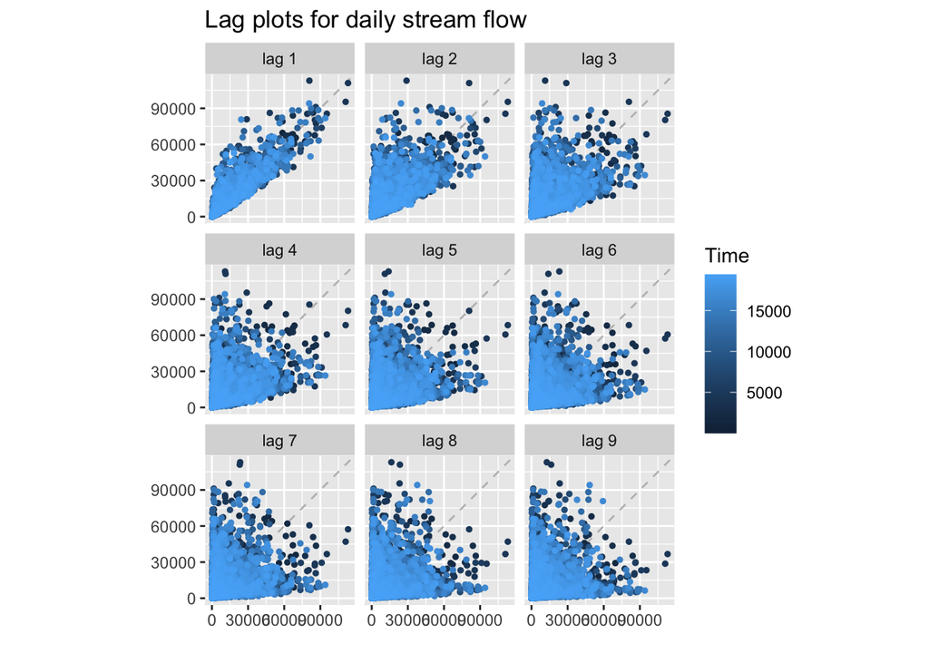

(a) Daily

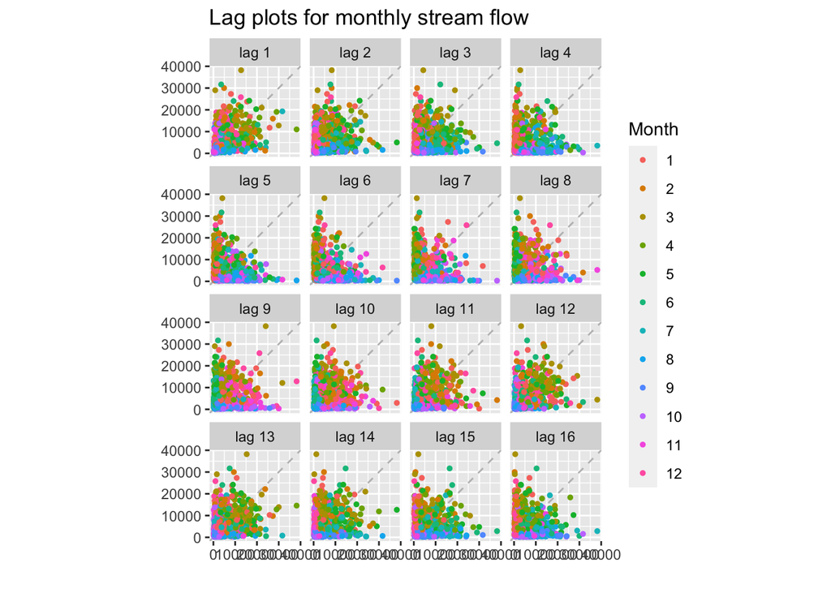

(b) Monthly

Figure 4: Lag plots for stream flow

```r
### can get monthly data
# Get mean value for each month
mean_data <- discharge_df %>%
  mutate(month = month(discharge.date), year = year(discharge.date)) %>%
  group_by(year, month) %>%
  summarize(mean_value = mean(discharge.discharge))

discharge_month<-ts(mean_data$mean_value,star=decimal_date(as.Date("1970-01-01",format = "%Y-%m-%d")),frequency = 12)



p <-gglagplot(discharge_ts, do.lines=FALSE)+
ggtitle(paste("Lag plots for daily stream flow"))
print(p)

p1 <-gglagplot(discharge_month, do.lines=FALSE)+
ggtitle(paste("Lag plots for monthly stream flow"))
print(p1)
```

Figure 4 shows the lag plot for daily and monthly stream flow discharge. For daily stream flow discharge (Figure 4 (a)), it shows the most related time is lag1, which makes sense that the next day stream flow discharge highly depends on the previous day. For monthly stream flow discharge (Figure 4 (b)), it seems there is no clear pattern.

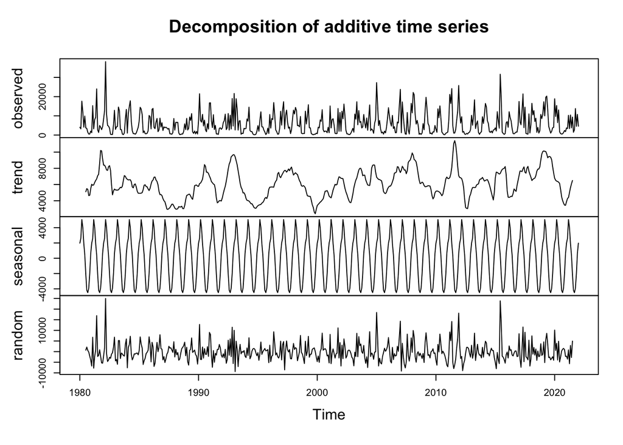

Figure 5: Decomposition of stream flow

```r
discharge_month2022 <- window(discharge_month,start=1980,end=2022)
decompose_discharge <- decompose(as.ts(discharge_month2022), "additive")
plot(decompose_discharge)
```

Figure 5 is the decomposition for monthly stream flow discharge. we can see the residual is more stationary compared to detrended daily stream flow discharge in Figure 2. Next, we will use ACF and PACF plot to see if the residual is stationary.

#### ACF and PACF

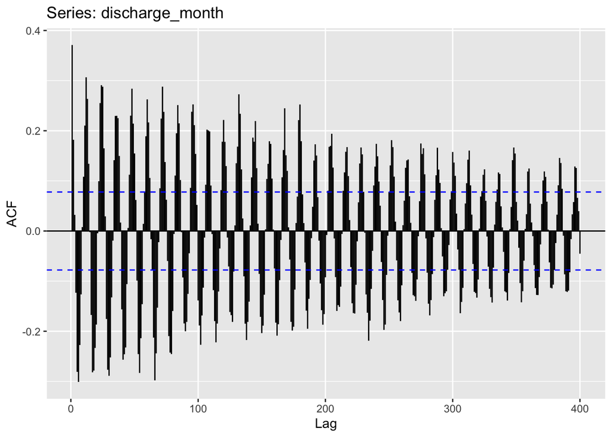

(a) ACF plot for monthly streamflow 1970-2022

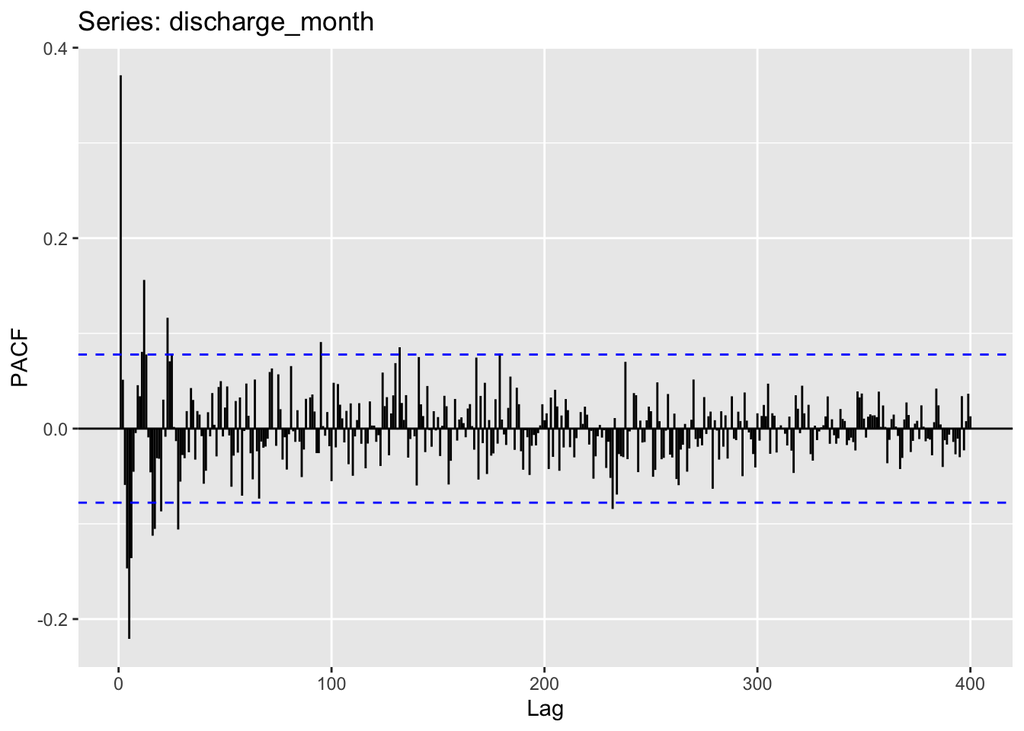

(b) PACF plot for monthly streamflow 1970-2022

Figure 6: ACF and PACF plots

```r
## ACF

ggAcf(discharge_month,400)
ggPacf(discharge_month,400)
```

```r
################ ADF Test #############
tseries::adf.test(discharge_month2022)
```

```
    Augmented Dickey-Fuller Test

data:  discharge_month2022
Dickey-Fuller = -10.302, Lag order = 7, p-value = 0.01
alternative hypothesis: stationary
```

```
    Augmented Dickey-Fuller Test

data:  window(detrend, 1981, 2020)
Dickey-Fuller = -14.646, Lag order = 7, p-value = 0.01
alternative hypothesis: stationary
```

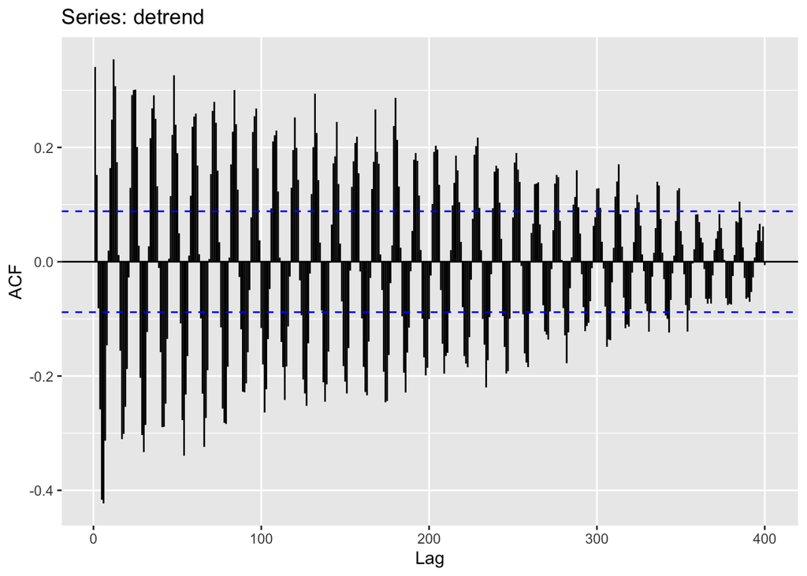

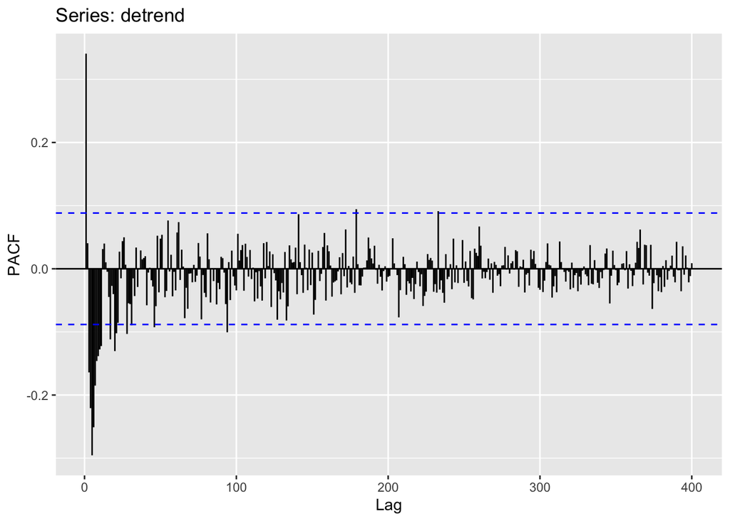

Figure 7: ACF and PACF plots

```r
## ACF
detrend <- discharge_month2022/decompose_discharge$trend
ggAcf(detrend,400)
ggPacf(detrend,400)

################ ADF Test #############
tseries::adf.test(window(detrend, 1981,2020))
```

#### Moving average smoothing

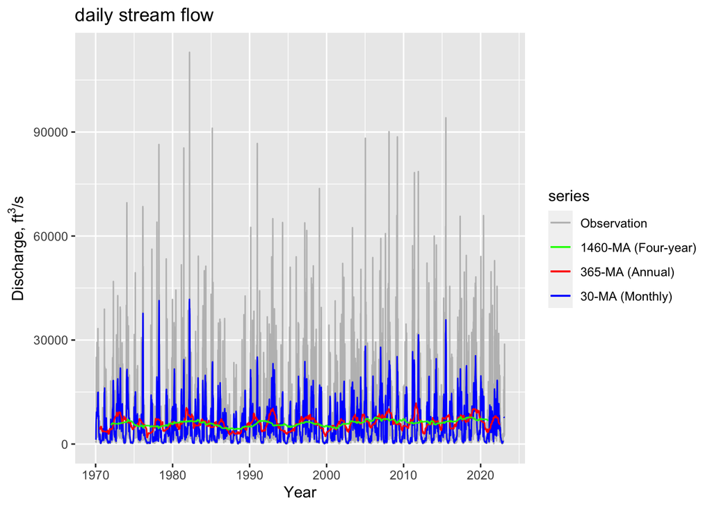

Figure 8: Moving average smoothing for daily stream flow

```r
## daily plot
discharge_daily <- ts(discharge$discharge,star=decimal_date(as.Date("1970-01-01",format = "%Y-%m-%d")),frequency = 365.25)

p <- autoplot(discharge_daily, series="Observation") +
  autolayer(ma(discharge_daily, 30), series="30-MA (Monthly)") +
  autolayer(ma(discharge_daily, 365), series="365-MA (Annual)") +
  autolayer(ma(discharge_daily, 1460), series="1460-MA (Four-year)") +
  xlab("Year") + ylab(expression(paste("Discharge, ",ft^3,"/s",sep=""))) +
  ggtitle("daily stream flow") +
  scale_colour_manual(values=c("Observation"="grey","1460-MA (Four-year)"="green","365-MA (Annual)"="red", "30-MA (Monthly)"="blue"),
                      breaks=c("Observation","1460-MA (Four-year)","365-MA (Annual)", "30-MA (Monthly)"))
p
```

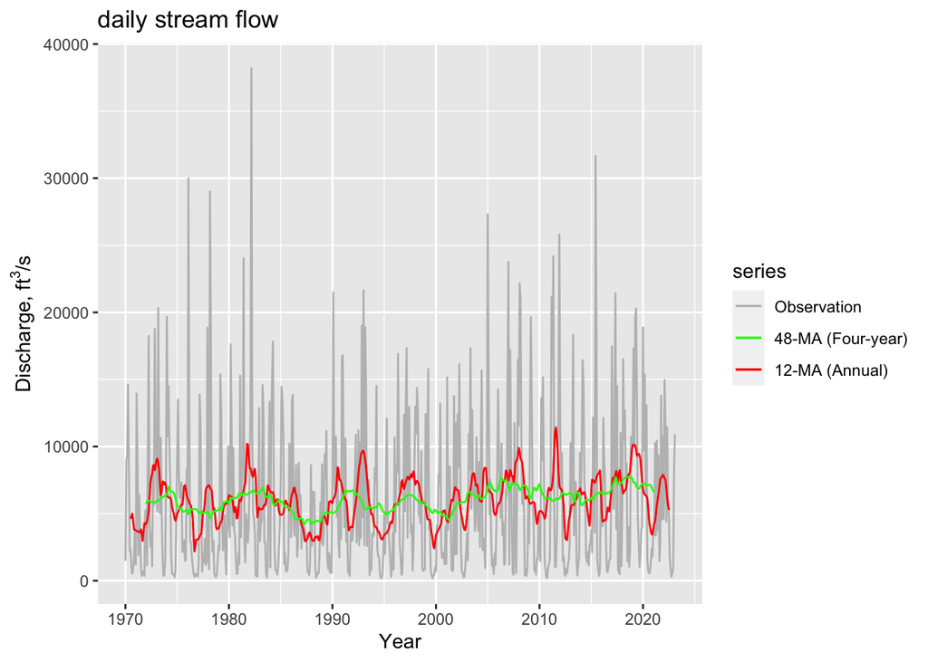

Figure 9: Moving average smoothing for monthly stream flow

```r
### can get monthly data
# Get mean value for each month
mean_data <- discharge %>%
  mutate(month = month(date), year = year(date)) %>%
  group_by(year, month) %>%
  summarize(mean_value = mean(as.numeric(as.vector(discharge)),na.rm = TRUE))
discharge_monthly<-ts(mean_data$mean_value,star=decimal_date(as.Date("1970-01-01",format = "%Y-%m-%d")),frequency = 12)

p <- autoplot(discharge_monthly, series="Observation") +
  autolayer(ma(discharge_monthly, 12), series="12-MA (Annual)") +
  autolayer(ma(discharge_monthly, 48), series="48-MA (Four-year)") +
  xlab("Year") + ylab(expression(paste("Discharge, ",ft^3,"/s",sep=""))) +
  ggtitle("daily stream flow") +
  scale_colour_manual(values=c("Observation"="grey","48-MA (Four-year)"="green","12-MA (Annual)"="red"),
                      breaks=c("Observation","48-MA (Four-year)","12-MA (Annual)"))
p
```

The annual moving average shows periodicity. Thus, a larger window, four-year window, is used to explore the pattern of the streamflow. we can see the four-year moving average is more stationary compared to others.